# Tree_CART_RF_XGBoost

## Tree Based Method (2) Random Forest

Now you understand Classification and Regression Trees, we introduce two algorithms that utilizes and improves upon the traditional CART. The first is Random forest, like its name implies, consists of a large number of individual decision trees that operate as an ensemble. For classification proble, each individual tree in the random forest spits out a class prediction and the class with the most votes becomes our model’s prediction; for regression, the predicted response is the average of the prediction from each tree.

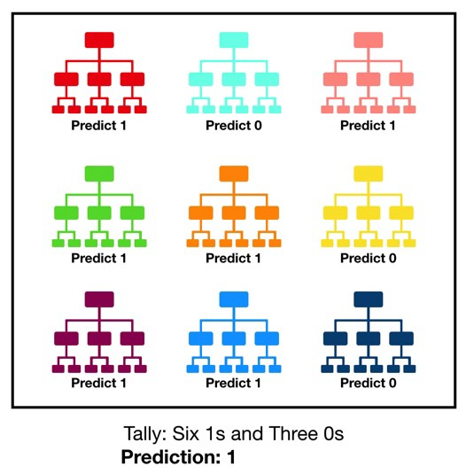

We build the model using the function randomForest. Notice the command “importance = TRUE” this specifies that the importance of predictors should be assessed.

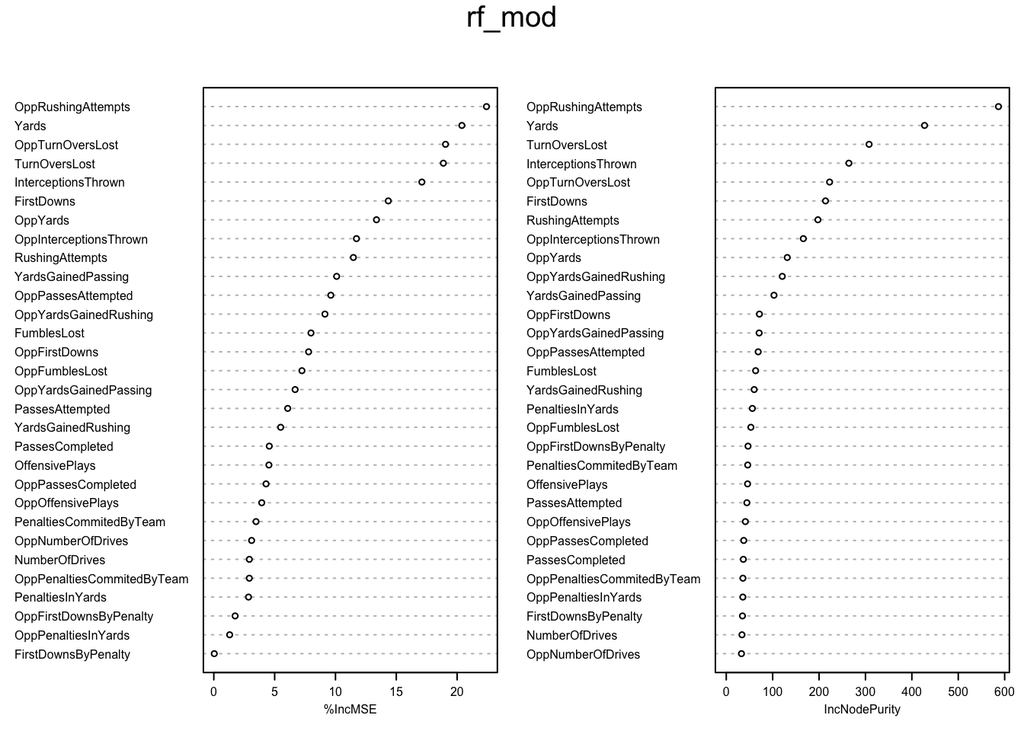

```r
rf_mod <- randomForest(Wins~. - ID, data = football_train, importance = TRUE)
varImpPlot (rf_mod, cex = 0.5)
```

We predict our result using random forest and plot the variable importance. You might be wondering how each of the variable importance is calculated:

#### Accuracy-based importance: using out-of-bag samples (left)

- prediction accuracy on the out-of-bag sample is measured.
- the values of the variable in the out-of-bag-sample are randomly shuffled, keeping all other variables the same.
- the decrease in prediction accuracy on the shuffled data is measured. (the variable that leads to the highest increase MSE is most important)

#### Gini-based importance (right)

- For each variable, the sum of the Gini decrease across every tree of the forest is accumulated every time that variable is chosen to split a node.
- The sum is divided by the number of trees in the forest to give an average.
- The larger the gini-based average, the more important the variable

```r
pred_rf <- predict(rf_mod, newdata = football_test)
rmse(actual = football_answers$Wins, predicted = pred_rf)
```

```
## [1] 1.634703
```

## Tree Based Method (3) XGBoost

Random Forest is an example of tree ensemble. In this section, we will introduce another decision tree based ensemble machine learning algorithm that uses gradient boosting frame work: XGBoost. - Boosting models are built sequentially by minimizing the errors from previous models while increasing (or boosting) influence of high performance models. - Gradient boosting models employs gradient descent algorithms to minimize errors in sequential models. - XGBoost optimized gradient boosting algorithm through parallel processing, tree_pruning, handling missing balues and regularization to avoid overfitting and bias, while also drastically decreasing the run time. (like gradient boosting models on steroids! )

Code: For XGBoost, we need to first convert the predictors into xgb.Dmatrix format, then we use xgboost function to model.

```r
train_values <- football_train[, !(names(football_train) == 'Wins' | names(football_train) == 'ID')]
train_result <- football_train$Wins
test_values <- football_test[, !(names(football_test) == 'ID')]
test_result <- football_answers$Wins
dtrain = xgb.DMatrix(data =  as.matrix(train_values), label = train_result)
dtest = xgb.DMatrix(data =  as.matrix(test_values), label = test_result)
watchlist = list(train=dtrain, test=dtest)
## training the XGBoost tree without tuning the parameter
model_xgb <- xgboost(data = dtrain, missing = NA, max.depth = 6, eta = 0.3, nthread = 4, nrounds = 16, verbose = 2, objective = "reg:linear")
```

```
## [13:43:51] WARNING: amalgamation/../src/objective/regression_obj.cu:152: reg:linear is now deprecated in favor of reg:squarederror.
```

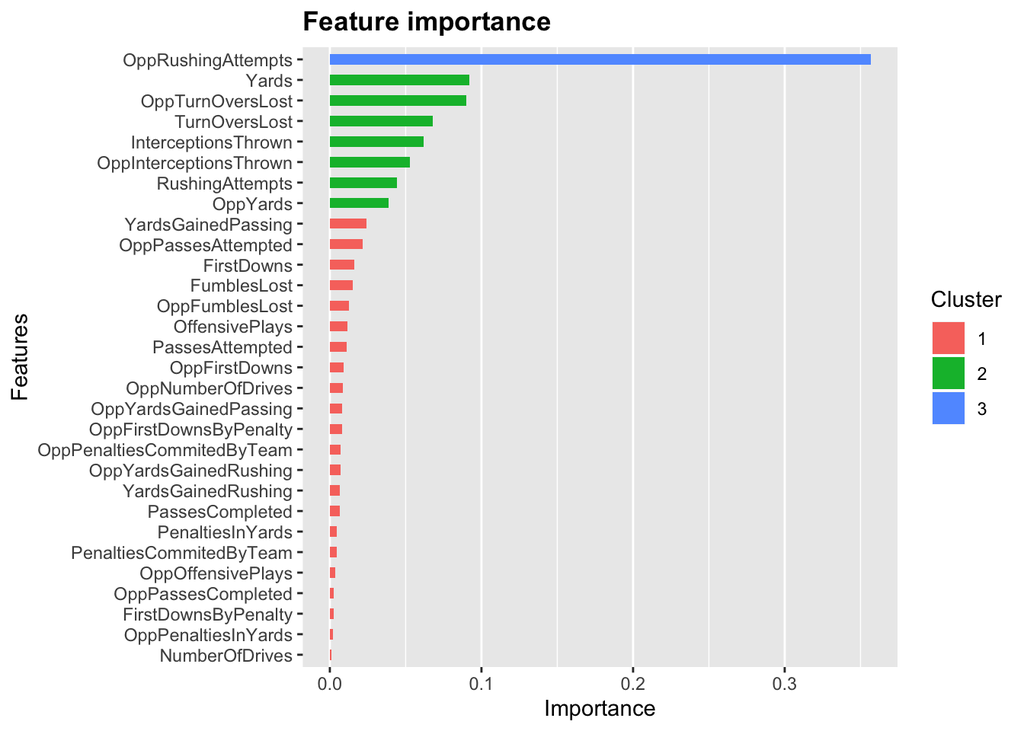

```r
imp_matrix <- xgb.importance(model = model_xgb)
xgb.ggplot.importance(importance_matrix = imp_matrix)
```

We found that oppRushingAttempts and yards are some of the most important variables. We test the prediction accuracy of our XGBoost model

```r
pred_xg <- predict(model_xgb , newdata = dtest)
rmse(actual = football_answers$Wins, predicted = pred_xg)
```

```
## [1] 1.803743
```

Hmmmm… It seems that XGBoost doesn’t perform as well as random forest. However, the variable selection are similar for Random Forest and XGBoost.

## The Package CARET

The caret package (short for Classification And REgression Training) is a set of functions that attempt to streamline the process for creating predictive models. The package contains tools for:

data splitting pre-processing feature selection model tuning using resampling variable importance estimation